# Weather and Morel mushroom observations

I’ll start by loading the morel observations into R. To review, I started with a dataset of about 1800 observations of morel mushrooms in the United States that were submitted to the website iNaturalist. I chose only those observations for which the location was certain to within a kilometer. In my last notebook, I explained how I got historical weather data from the Open Meteo API. I chose a random sample of the observations, for which the API returned information about the air temperature, soil temperature, humidity, and precipitation in the two weeks preceding the observation.

Because I don’t have data for the periods when morels were NOT observed, I won’t try to identify the factors that predict morel emergence. Rather, my goal is to explore the distribution of climate variables before the morels pop up to get and idea of what conditions are sufficient to give the woods explorer a chance of finding morels.

```r
morel_data <- read.csv("morchella_observations_and_weather_sample.csv")
```

```r
library(tidyverse)
library(jsonlite)
library(lubridate)
library(tibble)
```

The weather data are stored as JSON objects. I wrote a function to parse the data into tibbles. Before transforming the weather data, I’ll also deal with missing data. The API I used returned “None” if no data was available for a particular request. Fortunately in this case none of the rows had missing data.

```r
convert_from_json <- function(json){
  tmp <- fromJSON(json, simplifyDataFrame = TRUE)
  tmp <- as_tibble(tmp, name_repair="minimal")
  return (tmp)
}
```

```r
morel_data_filtered <- morel_data %>%
  filter(!str_detect(daily,"None")) %>%
  filter(!str_detect(hourly,"None"))
```

```r
daily_data <-
  mapply(convert_from_json, morel_data_filtered$daily, SIMPLIFY = FALSE)

hourly_data <-
  mapply(convert_from_json, morel_data_filtered$hourly, SIMPLIFY = FALSE)
```

```r
sample(daily_data, 1)
```

```
## $...
## # A tibble: 14 × 2
##    time       precipitation_sum
##    <chr>                  <dbl>
##  1 2022-04-08               1.2
##  2 2022-04-09               2.3
##  3 2022-04-10              19.7
##  4 2022-04-11              12.9
##  5 2022-04-12              11.4
##  6 2022-04-13               7.1
##  7 2022-04-14               3.2
##  8 2022-04-15               1
##  9 2022-04-16               2.9
## 10 2022-04-17               0
## 11 2022-04-18               9.3
## 12 2022-04-19              10.2
## 13 2022-04-20               5.1
## 14 2022-04-21               7.6
```

```r
sample(hourly_data, 1)
```

```
## $...
## # A tibble: 336 × 4
##    time             temperature_2m relativehumidity_2m soil_temperature_0_to_7cm
##    <chr>                     <dbl>               <int>                     <dbl>
##  1 2021-04-06T00:00           15.1                  55                      14.5
##  2 2021-04-06T01:00           14.8                  50                      14
##  3 2021-04-06T02:00           14.5                  49                      14
##  4 2021-04-06T03:00           14.2                  45                      14.2
##  5 2021-04-06T04:00           13                    45                      13.4
##  6 2021-04-06T05:00           11.3                  51                      12.2
##  7 2021-04-06T06:00           10.9                  52                      11.8
##  8 2021-04-06T07:00           11.7                  54                      11.7
##  9 2021-04-06T08:00           13.6                  42                      12.5
## 10 2021-04-06T09:00           15.2                  35                      13.6
## # … with 326 more rows
```

Very nice!

I might want to work with the data as dates and date-times rather than strings, so I’ll need to convert the data types. I’m also going to add a column called t_minus, which will allow me to order the findings by time without messing with confusing date/time syntax. I found selecting values from a data frame nested in another data frame a little confusing. Although I’m sure there are better ways to do this, I eventually worked this out:

```r
convert_tibble <- function(tibble,format){
  mutate(tibble, time = parse_date_time(time,format))
  mutate(tibble, t_minus=c((length(time)-1):0))
}

daily_data <- daily_data %>%
  lapply(convert_tibble,"ymd")


hourly_data <- hourly_data %>%
  lapply(convert_tibble,"ymdHM")
```

Now I’ll accumulate the data into a single data frame, which makes it easier to work with. Each observation will be tagged with an ID

```r
convert_to_dataframe <- function(dataset){
  dataset <- enframe(dataset)
  dataset['id'] <- c(1:length(dataset$value))
  dataset <- unnest(dataset, cols=c(value))
  return(dataset)
}

daily_data <- convert_to_dataframe(daily_data)
hourly_data <- convert_to_dataframe(hourly_data)
```

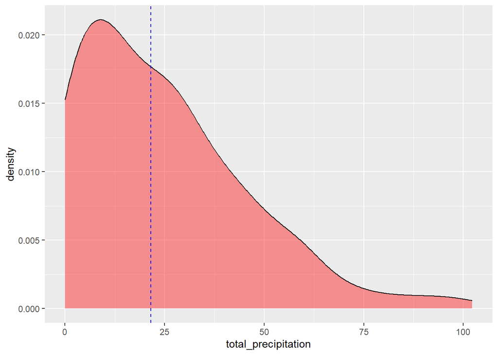

```r
rain_when_fruiting <- filter(daily_data, t_minus > 6)
totals_by_day <- rain_when_fruiting %>%
  group_by(id) %>%
  summarise(total_precipitation = sum(precipitation_sum))

ggplot(totals_by_day) + geom_density(mapping=aes(total_precipitation),fill="red", alpha=.4) + geom_vline(aes(xintercept=median(total_precipitation)), color="blue", linetype="dashed")
```

```r
count(totals_by_day[totals_by_day$total_precipitation <= 5, ]) / 200
```

| n |
| --- |
| 0.185 |

Next, I’ll examine humidity, air, and soil temperature data. First, I’ll plot the hourly data for each observation on a layered plot, then I’ll overlay the median temperature and quintile range (median chosen here instead of mean because there are some obvious outliers)

```r
get_summary_stats <- function(dataset, x_axis, y_axis){
  x <- dataset %>%
    group_by({{x_axis}}) %>%
      summarise(median = median({{y_axis}}), q20=unname(quantile({{y_axis}},probs=0.20)), q80=unname(quantile({{y_axis}},probs=0.80)))
  return(x)
}

temp_stats <- get_summary_stats(dataset = hourly_data, x_axis = t_minus, y_axis = temperature_2m)
humidity_stats <- get_summary_stats(hourly_data, t_minus, relativehumidity_2m)
soil_stats <- get_summary_stats(hourly_data, t_minus, soil_temperature_0_to_7cm)
```

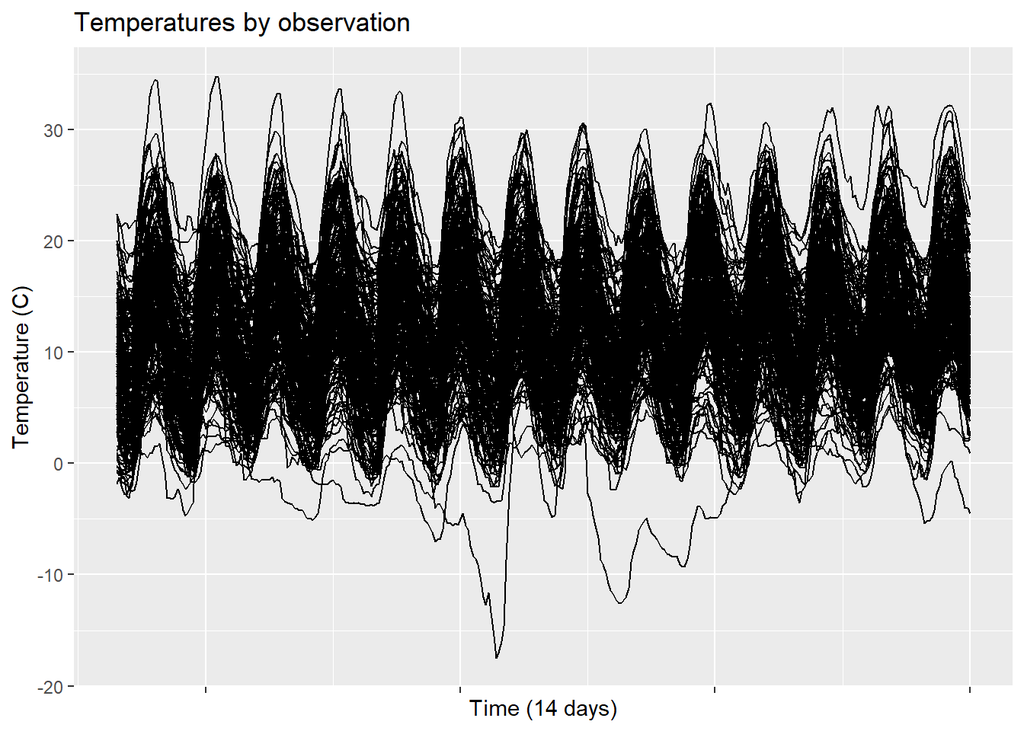

```r
plot_all_observations <- function(dataset,x,y,group, xlab=NULL, ylab=NULL){
  return(ggplot(dataset, mapping=aes(x={{x}},y={{y}})) + geom_line(aes(group={{group}})) + scale_x_reverse() + xlab(xlab) + ylab(ylab) + theme(axis.text.x = element_blank()))
}


plot_summary_stats <- function(dataset,x, xlab, ylab){
  return(ggplot(dataset, aes(x={{x}}))+ geom_line(mapping=aes(y=median), color="black", linewidth=0.5) + geom_ribbon(mapping=aes(ymin=q20,ymax=q80), color='red', alpha=0.2, fill='red') + scale_x_reverse() + xlab(xlab) + ylab(ylab) + theme(axis.text.x = element_blank()))

}

plot_all_observations(hourly_data,t_minus,temperature_2m,id,"Time (14 days)","Temperature (C)") + labs(title="Temperatures by observation")
```

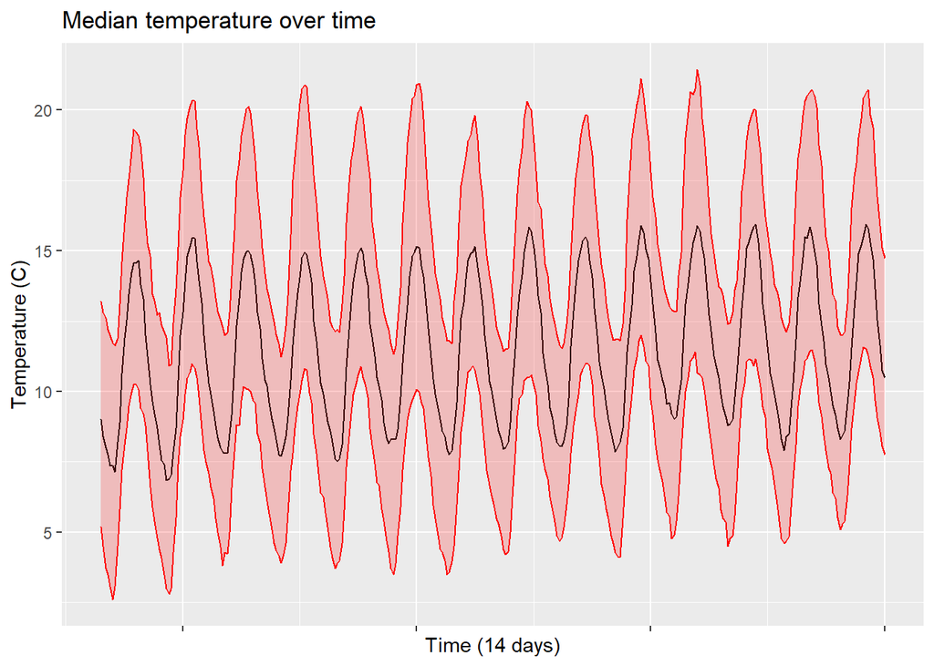

```r
plot_summary_stats(temp_stats,t_minus,"Time (14 days)","Temperature (C)") + labs(title="Median temperature over time")
```

We’ll do the same for soil temperature and humidity, respectively.

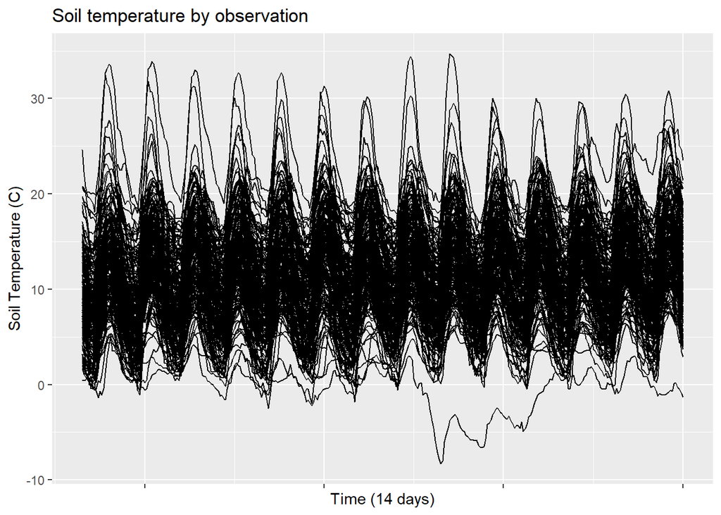

```r
plot_all_observations(hourly_data,t_minus,soil_temperature_0_to_7cm,id,"Time (14 days)","Soil Temperature (C)") + labs(title="Soil temperature by observation")
```

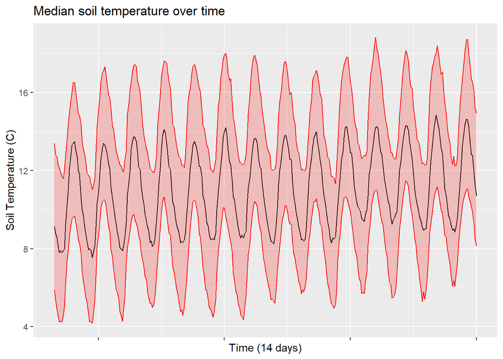

```r
plot_summary_stats(soil_stats,t_minus, "Time (14 days)", "Soil Temperature (C)") + labs(title='Median soil temperature over time')
```

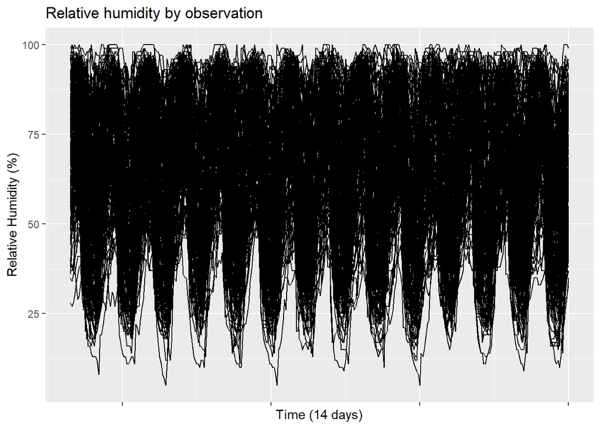

```r
plot_all_observations(hourly_data,t_minus,relativehumidity_2m,id,"Time (14 days)","Relative Humidity (%)") + labs(title="Relative humidity by observation")
```

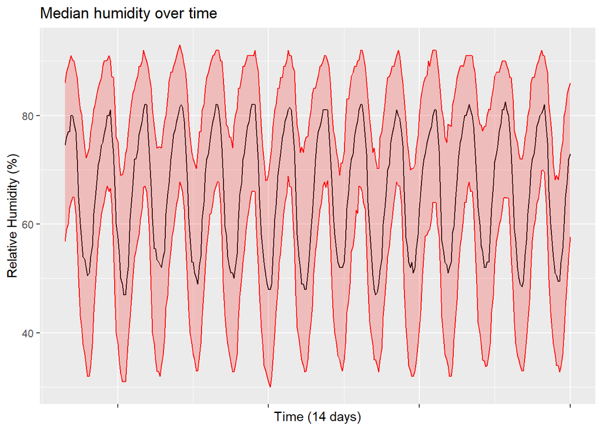

```r
plot_summary_stats(humidity_stats,t_minus,"Time (14 days)", "Relative Humidity (%)") + labs(title="Median humidity over time")
```

Here again we have a similar story: a fairly wide range of weather conditions allow for morel appearance. Of all the parameters, humidity seems the most restrictive, with a peak humidity of 65 - 90% bounding most of the observations. It will come as news to nobody that mushrooms prefer moist areas, but knowing the lower end the the range could help identify areas in the drier Western states where it may be worth it to hunt for morels. For instance, Flagstaff, AZ has an peak March daytime humidity of 66% and indeed, morels have been document there. Phoenix, on the other hand (50% peak humidity in March, April and May), is probably hopeless.

While I don’t think I’ve made any earth-shattering findings about morel ecology, I’m excited about how this relatively easy method of accessing historical weather data could be used to link historical weather data to any set of events. There are a lot of potential use cases here. To name a few:

- Identifying the weather variables that most strongly predict emergency department admissions for asthma.
- Creating a list of locations where rare species are most likely to be found
- Predicting the volume of Christmas shopping based on December weather